# PART 1: THE REPORT

# Homework 3

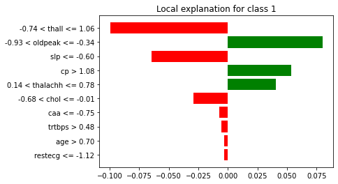

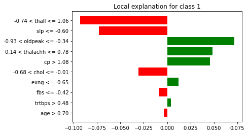

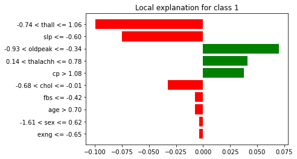

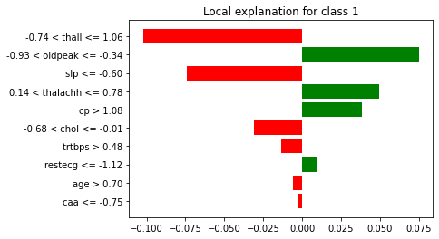

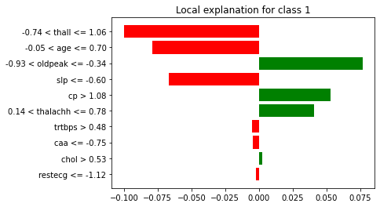

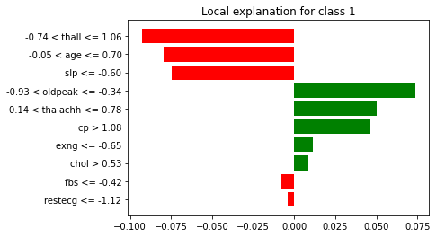

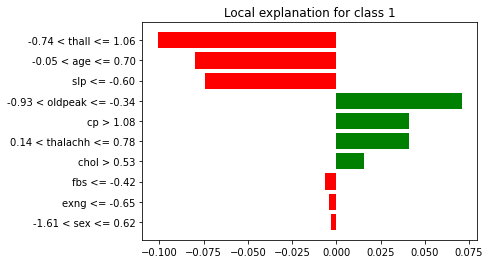

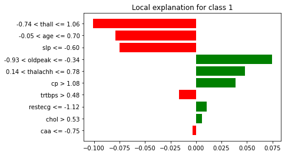

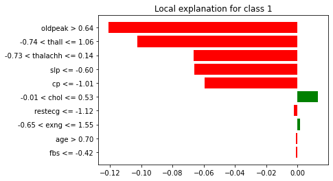

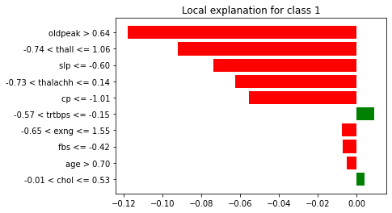

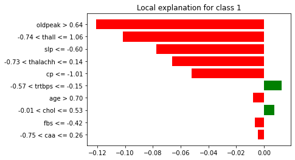

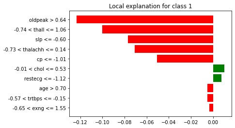

[4 more figures not shown]

While there is *some* variability with respect to the seed, it seems that the explanations are generally stable. The attributions do not vary significantly. It is likely due to the sample size - the results would vary much more if we weren't able to simply sample randomly, e.g. not in a tabular case.

```
Preparation of a new explainer is initiated

  -> data              : 61 rows 13 cols
  -> target variable   : 61 values
  -> model_class       : sklearn.ensemble._forest.RandomForestClassifier (default)
  -> label             : lr
  -> predict function  : <function yhat_proba_default at 0x7ff89dffb170> will be used (default)
  -> predict function  : Accepts pandas.DataFrame and numpy.ndarray.
  -> predicted values  : min = 0.04, mean = 0.543, max = 1.0
  -> model type        : classification will be used (default)
  -> residual function : difference between y and yhat (default)
  -> residuals         : min = -0.68, mean = 0.0141, max = 0.92
  -> model_info        : package sklearn

A new explainer has been created!
```

[interactive chart not shown]

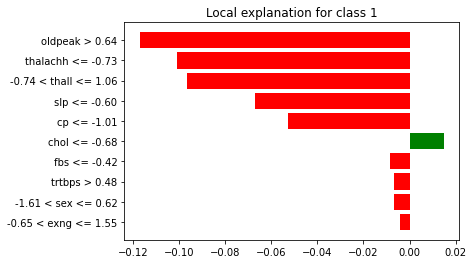

[interactive chart not shown]

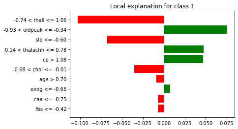

[interactive chart not shown]

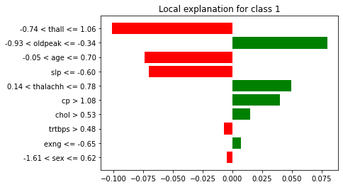

[interactive chart not shown]

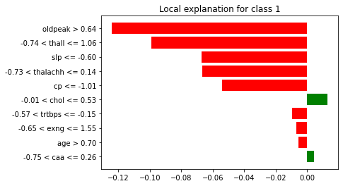

[interactive chart not shown]

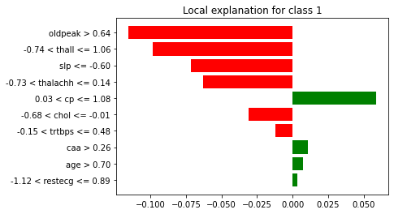

It seems that the main difference between the explanations is that SHAP often attributes larger weights to single attributes, while LIME seems more conservative, distributing the effect more smoothly across features

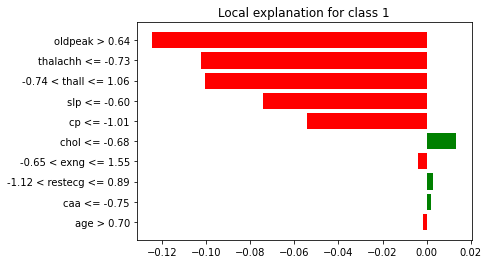

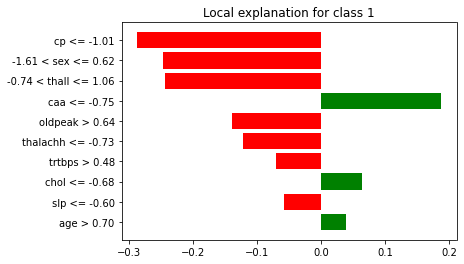

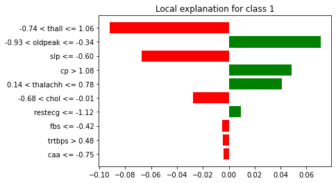

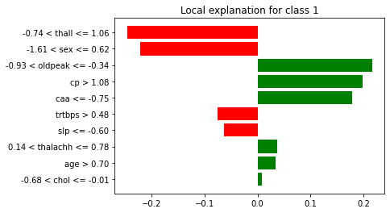

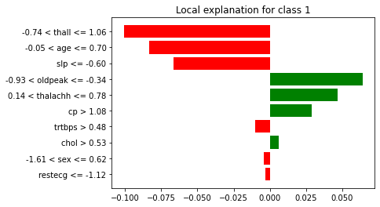

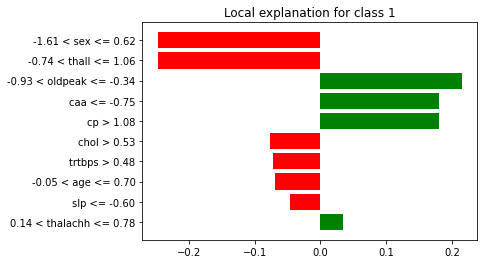

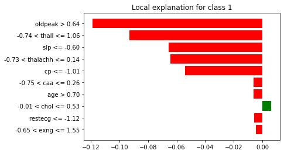

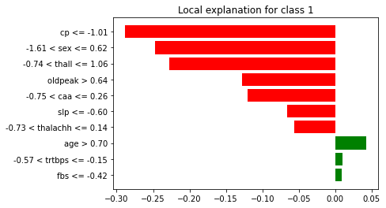

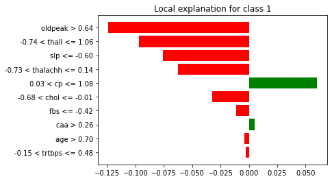

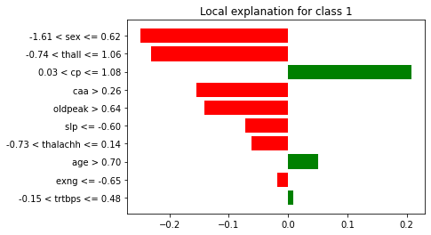

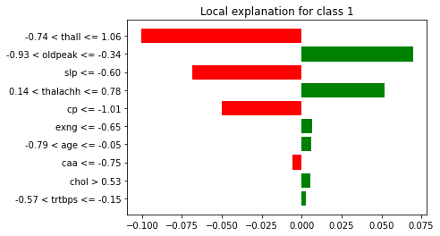

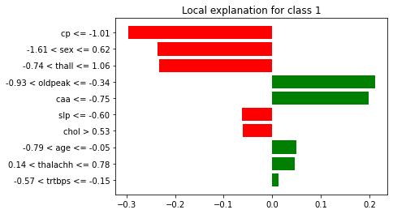

[2 more figures not shown]

A very interesting phenomenon - the shapes of the plots are near identical, yet the two models emphasise very different attributes. Another observation - the magnitudes for GBM are much larger than for Random Forest. It seems that the learned curvatures for GBM are much "ragged", or less smooth, than those of RF.

CONCLUSION: The LIME explanations are stable for tabular data, since we can sample to our heart's content, and first order approximations are usually pretty stable, unless we are at a high curvature point or have very few points (think images or NLP). LIME seems to produce smoother explanations than SHAP, where SHAP seems to tend to pick a favourite feature and attribute considerable weight to it. It might be a local artifact, though. There were systematic differences between observations for the two types of tree models - we learned that the GBM model likely produces mmuch more ragged/wavy curves than RF. Interestingly, though, the relative magnitude distribution for both models seemed very similar (though for absolutely different features).

# APPENDIX: CODE FROM FIRST 3 HOMEWORKS (SAME CODEBASE)

# HEART ATTACK ANALYSIS AND PREDICTION💔

- IMPORT FILES
- GET THE DATA
- EDA
- DATA VISUALIZATION
- DATA PREPROCESSING
- MODELS

```
/kaggle/input/heart-attack-analysis-prediction-dataset/o2Saturation.csv
/kaggle/input/heart-attack-analysis-prediction-dataset/heart.csv
```

> Data Dictionary

age - Age of the patient

sex - Sex of the patient

cp - Chest pain type ~ 0 = Typical Angina, 1 = Atypical Angina, 2 = Non-anginal Pain, 3 = Asymptomatic

trtbps - Resting blood pressure (in mm Hg)

chol - Cholesterol in mg/dl fetched via BMI sensor

fbs - (fasting blood sugar > 120 mg/dl) ~ 1 = True, 0 = False

restecg - Resting electrocardiographic results ~ 0 = Normal, 1 = ST-T wave normality, 2 = Left ventricular hypertrophy

thalachh - Maximum heart rate achieved

oldpeak - Previous peak

slp - Slope

caa - Number of major vessels

thall - Thalium Stress Test result ~ (0,3)

exng - Exercise induced angina ~ 1 = Yes, 0 = No

output - Target variable

# IMPORT FILES

Importing all my required libraries for this notebook.

# GET THE DATA

Fetching data from CSV file.

# Get to know the data

The main purpose of EDA is to help look at data before making any assumptions.

|  | age | sex | cp | trtbps | chol | fbs | restecg | thalachh | exng | oldpeak | slp | caa | thall | output |
| --- | --- | --- | --- | --- | --- | --- | --- | --- | --- | --- | --- | --- | --- | --- |
| 0 | 63 | 1 | 3 | 145 | 233 | 1 | 0 | 150 | 0 | 2.3 | 0 | 0 | 1 | 1 |
| 1 | 37 | 1 | 2 | 130 | 250 | 0 | 1 | 187 | 0 | 3.5 | 0 | 0 | 2 | 1 |
| 2 | 41 | 0 | 1 | 130 | 204 | 0 | 0 | 172 | 0 | 1.4 | 2 | 0 | 2 | 1 |
| 3 | 56 | 1 | 1 | 120 | 236 | 0 | 1 | 178 | 0 | 0.8 | 2 | 0 | 2 | 1 |
| 4 | 57 | 0 | 0 | 120 | 354 | 0 | 1 | 163 | 1 | 0.6 | 2 | 0 | 2 | 1 |

|  | age | sex | cp | trtbps | chol | fbs | restecg | thalachh | exng | oldpeak | slp | caa | thall | output |
| --- | --- | --- | --- | --- | --- | --- | --- | --- | --- | --- | --- | --- | --- | --- |
| count | 303.000000 | 303.000000 | 303.000000 | 303.000000 | 303.000000 | 303.000000 | 303.000000 | 303.000000 | 303.000000 | 303.000000 | 303.000000 | 303.000000 | 303.000000 | 303.000000 |
| mean | 54.366337 | 0.683168 | 0.966997 | 131.623762 | 246.264026 | 0.148515 | 0.528053 | 149.646865 | 0.326733 | 1.039604 | 1.399340 | 0.729373 | 2.313531 | 0.544554 |
| std | 9.082101 | 0.466011 | 1.032052 | 17.538143 | 51.830751 | 0.356198 | 0.525860 | 22.905161 | 0.469794 | 1.161075 | 0.616226 | 1.022606 | 0.612277 | 0.498835 |
| min | 29.000000 | 0.000000 | 0.000000 | 94.000000 | 126.000000 | 0.000000 | 0.000000 | 71.000000 | 0.000000 | 0.000000 | 0.000000 | 0.000000 | 0.000000 | 0.000000 |
| 25% | 47.500000 | 0.000000 | 0.000000 | 120.000000 | 211.000000 | 0.000000 | 0.000000 | 133.500000 | 0.000000 | 0.000000 | 1.000000 | 0.000000 | 2.000000 | 0.000000 |
| 50% | 55.000000 | 1.000000 | 1.000000 | 130.000000 | 240.000000 | 0.000000 | 1.000000 | 153.000000 | 0.000000 | 0.800000 | 1.000000 | 0.000000 | 2.000000 | 1.000000 |
| 75% | 61.000000 | 1.000000 | 2.000000 | 140.000000 | 274.500000 | 0.000000 | 1.000000 | 166.000000 | 1.000000 | 1.600000 | 2.000000 | 1.000000 | 3.000000 | 1.000000 |
| max | 77.000000 | 1.000000 | 3.000000 | 200.000000 | 564.000000 | 1.000000 | 2.000000 | 202.000000 | 1.000000 | 6.200000 | 2.000000 | 4.000000 | 3.000000 | 1.000000 |

```
Index(['age', 'sex', 'cp', 'trtbps', 'chol', 'fbs', 'restecg', 'thalachh',
       'exng', 'oldpeak', 'slp', 'caa', 'thall', 'output'],
      dtype='object')
```

```
54.366336633663366
```

```
age         0
sex         0
cp          0
trtbps      0
chol        0
fbs         0
restecg     0
thalachh    0
exng        0
oldpeak     0
slp         0
caa         0
thall       0
output      0
dtype: int64
```